# Optimization formulation with LLM assistance

## Optimization formulation with LLM assistance

- 60-minute LLM formulation activity
- 120-minute examination preparation
- 2105623 5 October 2026

## Learning targets

- Translate a process description into variables, an objective, and constraints.
- Explain the units and physical meaning of every equation.
- Audit an LLM proposal with counterexamples and independent checks.
- Defend the model before interpreting its optimum.

## Three-hour session

| Minutes | Activity |
| --- | --- |
| 0–15 | Independent formulation of a blending LP |
| 15–40 | LLM draft, counterexamples, and Pyomo checks |
| 40–60 | MILP pair activity and discussion |
| 60–70 | Break |
| 70–120 | LP and MILP examination review |
| 120–160 | Individual mock examination |
| 160–180 | Solutions and final checklist |

## Case A: the production assignment

- A chemical plant blends two liquid feeds, A and B, to make a solvent mixture for a customer.
- The customer requires exactly 100 metric tonnes of product per day. The plant must supply the full amount each day.
- The product may contain at most 5 wt% of an impurity. This means no more than 5 kg of impurity per 100 kg of product.
- As the process engineer, choose the daily amount of each feed to minimize the total daily feed purchase cost.

## Case A: feed data and units

| Feed | Cost (USD/t) | Impurity (wt%) | Availability (t/day) |
| --- | --- | --- | --- |
| A | 100 | 2 | 100 |
| B | 60 | 10 | 80 |

**Prices apply to total feed mass, including impurity. Availability is an upper limit on daily purchases.**

## Case A: operating conditions

- The feeds mix completely. No reaction, evaporation, separation, or mass loss occurs. All feed mass becomes product.
- The plant consumes all purchased feed that day. It holds no inventory and allows no shortage, extra production, or disposal.
- Feed quantities are continuous. Either feed may be unused. The only feed limits are the stated daily availabilities.
- Mixing capacity is sufficient. Other operating costs are constant, and neither supplier charges a fixed fee in Case A.

## Case A: independent formulation

- Write each decision variable and its unit.
- Write the cost objective and the total mass balance.
- Write a contaminant balance inequality without a variable denominator.
- State the variable bounds and classify the model.

## Case A: variables and objective

x_A, x_B = feed mass flow rates (t/day)

minimize z = 100 x_A + 60 x_B

0 ≤ x_A ≤ 100 and 0 ≤ x_B ≤ 80

**Objective units: (USD/t) × (t/day) = USD/day.**

## Case A: balances and quality

x_A + x_B = 100

0.02 x_A + 0.10 x_B ≤ 0.05 × 100

**Both sides of the quality inequality have units of impurity t/day.**

## Case A: an analytic check

x_A = 100 − x_B

2 + 0.08 x_B ≤ 5, so x_B ≤ 37.5

z = 10,000 − 40 x_B

**The cheapest feasible blend uses A = 62.5 and B = 37.5 t/day. Cost = 8,500 USD/day.**

## LLM assistance in the modeling workflow

- Draft: extract data, decisions, and unresolved ambiguities.
- Review: link every equation to a sentence in the problem.
- Challenge: seek a counterexample and inspect units.
- Implement: translate the accepted equations into Pyomo.

## Prompt 1: formulation before code

```
Act as an optimization modeling tutor.
List sets, parameters, variables, domains, and units.
Identify missing information. Do not invent data.
Write the objective and constraints.
Map each equation to a sentence in the problem.
Check units and classify the model.
Do not write code yet.
```

## Ambiguity needs an explicit assumption

- “Meet demand” could mean exactly the demand or at least that amount.
- A stated capacity might apply per hour, per shift, or per day.
- “Use feed B” might mean purchasing, consuming, or activating a supplier.
- The modeler resolves these choices and records the assumption.

**When the problem leaves a material choice unclear, ask before inserting a number.**

## Audit exercise: a flawed draft

minimize 100 x_A + 60 x_B

x_A + x_B ≤ 100

0.02 x_A + 0.10 x_B ≤ 0.05

x_A ≥ 0, x_B ≥ 0

**Find the missing or incorrect requirements. This is a deliberately constructed draft, not a recorded LLM response.**

## Counterexamples expose semantic errors

| Test | Flawed draft | Correct Case A |
| --- | --- | --- |
| A = 0, B = 0 | Allowed | Fails the 100 t/day requirement |
| A = 62.5, B = 37.5 | Rejected by wrong quality RHS | Feasible, impurity = 5 wt% |
| A = 20, B = 80 | Rejected | Rejected, impurity = 8.4 wt% |

**A model audit checks what the equations allow and exclude.**

## Prompt 2: adversarial model review

```
Review this formulation without rewriting it first.
For each constraint, identify its physical meaning and units.
Find a point that the equations allow but the problem forbids.
Find a point that the problem allows but the equations exclude.
Check variable bounds and missing balances.
State what you could not verify.
```

## Pyomo mirrors the accepted equations

```python
import pyomo.environ as p
m = p.ConcreteModel()
m.A = p.Var(bounds=(0, 100))
m.B = p.Var(bounds=(0, 80))
m.mass = p.Constraint(expr=m.A + m.B == 100)
m.quality = p.Constraint(
    expr=0.02*m.A + 0.10*m.B <= 5)
m.obj = p.Objective(expr=100*m.A + 60*m.B)
```

## Verification after solving

```python
solver = p.SolverFactory("appsi_highs")
result = solver.solve(m, load_solutions=False)
assert p.check_optimal_termination(result)
m.solutions.load_from(result)
a, b = p.value(m.A), p.value(m.B)
assert abs(a + b - 100) < 1e-6
assert 0.02*a + 0.10*b <= 5 + 1e-6
```

**Also check availability, domains, and the objective with an independent calculation.**

## Case B: the supplier contract

- The plant still makes exactly 100 t/day with at most 5 wt% impurity. Feed prices, compositions, and operating conditions remain as in Case A.
- Supplier B now offers an optional daily contract. Activating it costs 1,200 USD for that day, in addition to 60 USD per tonne of B.
- An active contract requires the plant to purchase and consume between 20 and 80 t/day of B. With no contract, B supply is zero.
- Supplier A remains available at 100 USD/t, up to 100 t/day, with no fixed charge or minimum purchase.

## Case B: the engineering decision

- Decide whether to activate supplier B and how many tonnes per day to obtain from each supplier.
- Minimize daily feed purchases plus the daily activation fee. The product quantity and impurity specification must still hold.
- First describe what an inactive and an active contract permit. Then choose variable domains and write the MILP formulation.
- After solving, report the contract decision, both feed quantities, product impurity, and total daily cost. Compare with using only A.

## Activation and minimum-lot constraints

y_B ∈ {0, 1}

20 y_B ≤ x_B ≤ 80 y_B

minimize 100 x_A + 60 x_B + 1,200 y_B

**Keep the mass balance, quality inequality, and feed bounds from Case A.**

## Pair exercise: logic and an AI audit

- Supplier B raises its minimum daily order from 20 to 40 t. The maximum remains 80 t/day and the fixed fee remains 1,200 USD/day.
- Keep all other Case B data, including exactly 100 t/day of product and at most 5 wt% impurity. Revise the formulation.
- Before solving, decide whether an active B contract can meet product quality. Ask an LLM to audit your logic and upper bound.
- Submit the revised constraints and a numerical test of an active contract. State the optimal purchasing plan and daily cost.

**10 minutes in pairs. Your explanation must stand on its own.**

## Common logical mistakes

| Claim | What the equation actually says |
| --- | --- |
| x_B ≤ M y_B means active implies flow | Active permits zero flow unless a lower bound applies |
| y_B ≤ y_A means A requires B | It means B requires A |
| x_B y_B is needed to charge activation | A fixed charge uses F y_B |
| An arbitrary large M is harmless | It can weaken the relaxation and numerical behavior |

## Activity reflection

- What did the LLM help you express or notice?
- Which proposed equation needed correction?
- What numerical evidence supports your correction?

**Keep your original formulation, AI draft, and corrected version.**

## Break

- 10 minutes
- Next: examination preparation

## Diagnostic: five modeling decisions

- 1. Is production a parameter or a decision variable?
- 2. Does “at most 80 t/day” require ≤, =, or ≥?
- 3. What are the units of concentration × flow?
- 4. Does x ≤ My force production when y = 1?
- 5. What does an optimal solver result establish?

## Diagnostic: reasoning

- Production is a decision when the planner can choose it.
- “At most” gives an upper bound. A flow cap has units of flow.
- Mass fraction × mass flow gives contaminant mass flow.
- x ≤ My forces x = 0 when y = 0, if x ≥ 0.
- Optimality concerns the encoded model under the solver’s criteria.

## A formulation has a traceable structure

- Sets and indices define what the model distinguishes.
- Parameters contain supplied data with units.
- Decision variables describe controllable quantities and their domains.
- The objective measures the stated goal. Each constraint traces to a requirement.

## Case A: the feasible blends

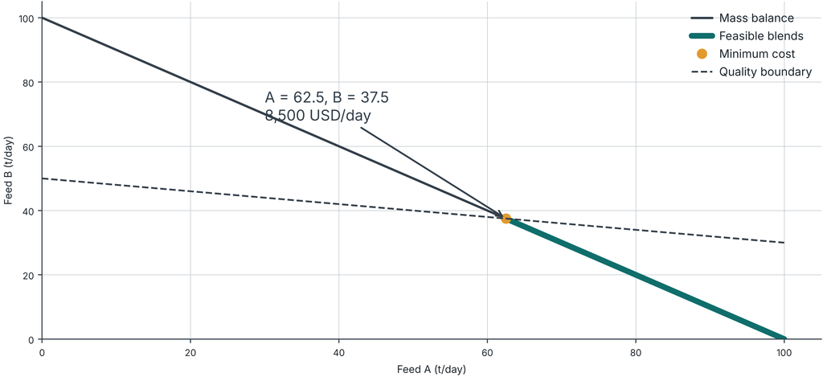

## Quality changes the cheapest recipe

| Maximum impurity | A (t/day) | B (t/day) | Cost (USD/day) |
| --- | --- | --- | --- |
| 4 wt% | 75 | 25 | 9,000 |
| 5 wt% | 62.5 | 37.5 | 8,500 |
| 6 wt% | 50 | 50 | 8,000 |

**Predict the direction before reading the numbers. Which constraint sets the recipe?**

## A tighter upper bound improves the relaxation

Quality and mass balance imply x_B ≤ 37.5

Therefore: 20 y_B ≤ x_B ≤ 37.5 y_B

| Formulation | LP relaxation cost (USD/day) |
| --- | --- |
| Availability bound M = 80 | 9,062.50 |
| Quality bound M = 37.5 | 9,700.00 |
| Integer optimum | 9,700.00 |

## The activation fee changes the preferred plan

| B activation fee | A (t/day) | B (t/day) | Total cost (USD/day) |
| --- | --- | --- | --- |
| 1,200 USD/day | 62.5 | 37.5 | 9,700 |
| 1,800 USD/day | 100 | 0 | 10,000 |

**Maximum variable-cost saving = 40 × 37.5 = 1,500 USD/day.**

## Mock examination: production with inventory

- 40 minutes, including reading time.
- Write a complete formulation and justify the decisions.
- Use an independent attempt before consulting any tool.
- The instructor will specify permitted tools for this practice.

**The actual examination follows the course’s announced rules.**

## Mock case: two production periods

| Parameter | Period 1 | Period 2 |
| --- | --- | --- |
| Demand (t) | 40 | 60 |
| Production cost (USD/t) | 5 | 8 |
| Production capacity (t/period) | 80 | 80 |
| Setup cost (USD/period) | 100 | 100 |

**Initial and final inventory are zero. Carrying 1 t from period 1 to period 2 costs 1 USD. Meet every demand on time. No backlog or disposal.**

## Mock case: tasks and marks

| Task | Marks |
| --- | --- |
| Variables, domains, and units | 3 |
| Objective with all cost terms | 4 |
| Period balances and boundary conditions | 4 |
| Production/setup linkage | 3 |
| Model class and assumptions | 2 |
| Optimal plan and capacity interpretation | 4 |

**Find the optimal plan. Then predict the effect of increasing period-1 capacity from 80 to 100 t.**

## Mock solution: formulation

x_t ≥ 0, s_t ≥ 0, y_t ∈ {0,1}, t = 1,2

minimize 5x₁ + 8x₂ + s₁ + 100(y₁ + y₂)

s_(t−1) + x_t = d_t + s_t

x_t ≤ 80 y_t, s₀ = 0, s₂ = 0

**x and s are tonnes. Each y indicates whether the period incurs setup cost.**

## Mock solution: the optimal plan

| Quantity | Period 1 | Period 2 |
| --- | --- | --- |
| Production (t) | 80 | 20 |
| Closing inventory (t) | 40 | 0 |
| Setup indicator | 1 | 1 |

**Production: 560 USD. Holding: 40 USD. Setups: 200 USD. Total: 800 USD.**

## Capacity can remove an entire setup

| Period-1 capacity | Production (t) | Setups | Total cost (USD) |
| --- | --- | --- | --- |
| 80 t | 80, 20 | Both periods | 800 |
| 100 t | 100, 0 | Period 1 only | 660 |

**The 140 USD saving combines cheaper early production with removal of period-2 setup.**

## A final model audit

- Every variable has a meaning, unit, and domain.
- Every required balance includes its boundary conditions.
- Every implication works in both binary states.
- Every big-M follows from a valid bound.
- One feasible point and one rejected point agree with the problem.
- The reported optimum passes physical and numerical checks.

## References and teaching materials

- Pyomo documentation: www.pyomo.org/documentation
- NL4Opt competition report: arxiv.org/abs/2303.08233
- Course books and Interactive Lab: www.skhgroup.net/teaching/2105623/
- The blending and mock-exam data in this deck are synthetic.